# Model comparison

The PSIS-LOO approximation to LOO can only be trusted if Pareto k estimates are smaller than 0.5.

Next we will fit our null model (using more iterations than the default, as per Stan’s recommendation).

```r
fit_null_varying_effects <- brm(response ~ 1 + (treatment | subject),
                    prior = prior(lkj(2), class = cor),
                    data = d,
                    iter = 4000,
                    file = "../../models/fit_loo_null",
                    file_refit = "on_change")
```

```r
loo_fit_null_varying_effects <- loo(fit_null_varying_effects)

loo_fit_null_varying_effects
```

```
Computed from 8000 by 1200 log-likelihood matrix

         Estimate   SE
elpd_loo   -911.5 24.7
p_loo        58.9  2.4
looic      1823.0 49.5
------
Monte Carlo SE of elpd_loo is 0.1.

All Pareto k estimates are good (k < 0.5).
See help('pareto-k-diagnostic') for details.
```

To compare the models, we need to look at the difference between `elpd_loo` and the standard error (`SE`) of that difference:

```r
loo_compare(loo_fit1, loo_fit_null_varying_effects)
```

```
                         elpd_diff se_diff
fit_null_varying_effects  0.0       0.0
fit1                     -0.4       0.3
```

The difference in `elpd_loo` is not bigger than two times the `SD` (rule of thumb), meaning that from the perspective of LOO, the models are almost indistinguishable.

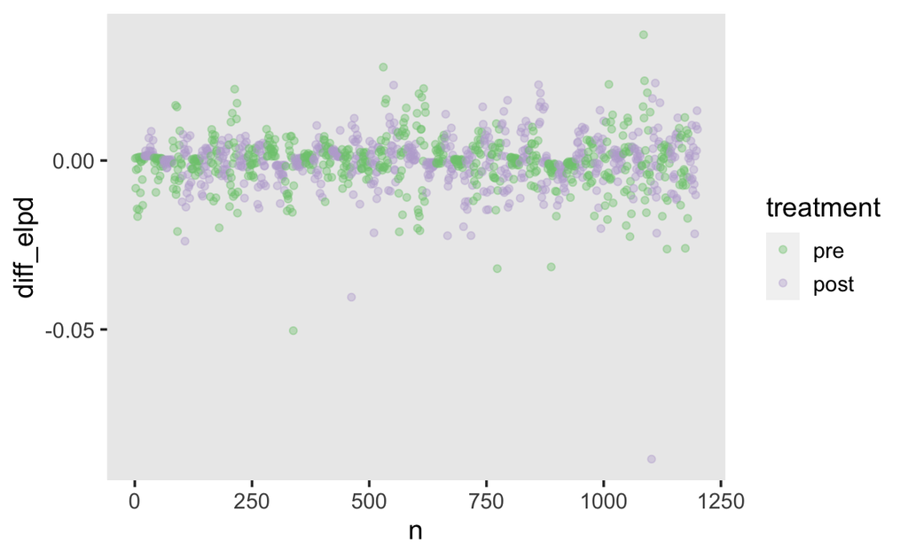

```r
d <- mutate(d,
            n = row_number(),
            diff_elpd = loo_fit1$pointwise[,"elpd_loo"] -
                        loo_fit_null_varying_effects$pointwise[,"elpd_loo"])

d |>
  ggplot(aes(x = n, y = diff_elpd, color = treatment)) +
  geom_point(alpha = .4, position = position_jitter(w = 0.01, h = 0)) +
  scale_color_brewer(type = "qual")
```

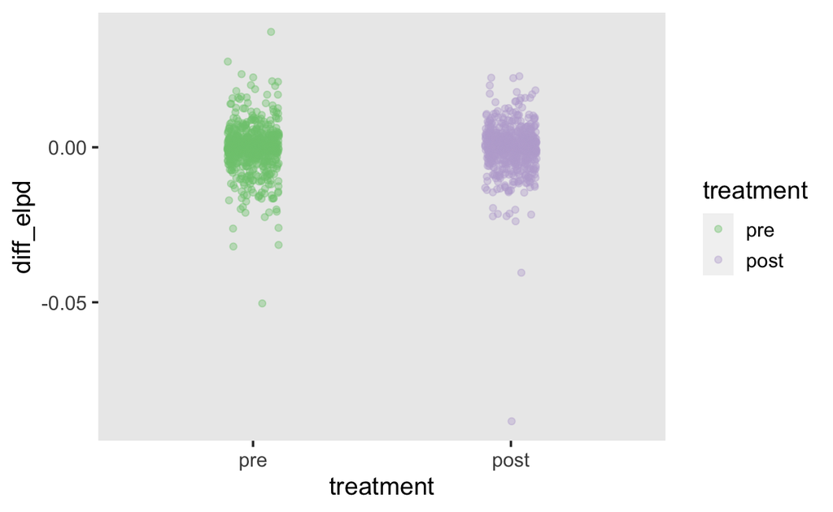

```r
d |>
  ggplot(aes(x = treatment, y = diff_elpd, color = treatment)) +
  geom_point(alpha = .4, position = position_jitter(w = 0.1, h = 0)) +
  scale_color_brewer(type = "qual")
```

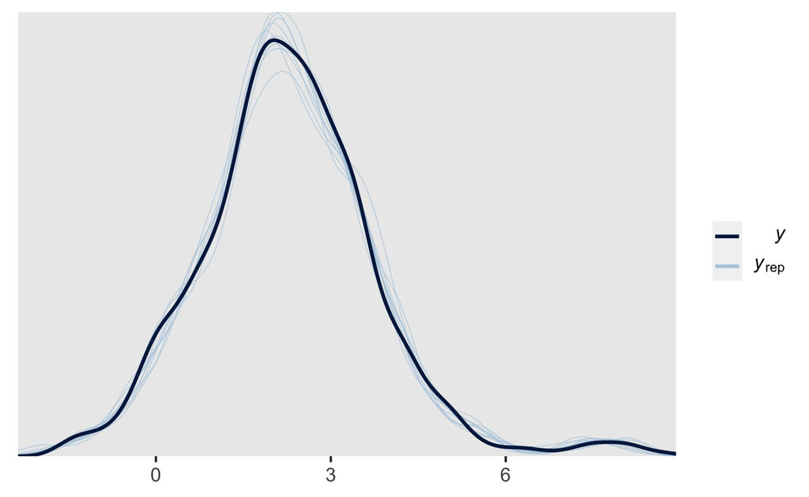

```r
pp_check(fit1)
```

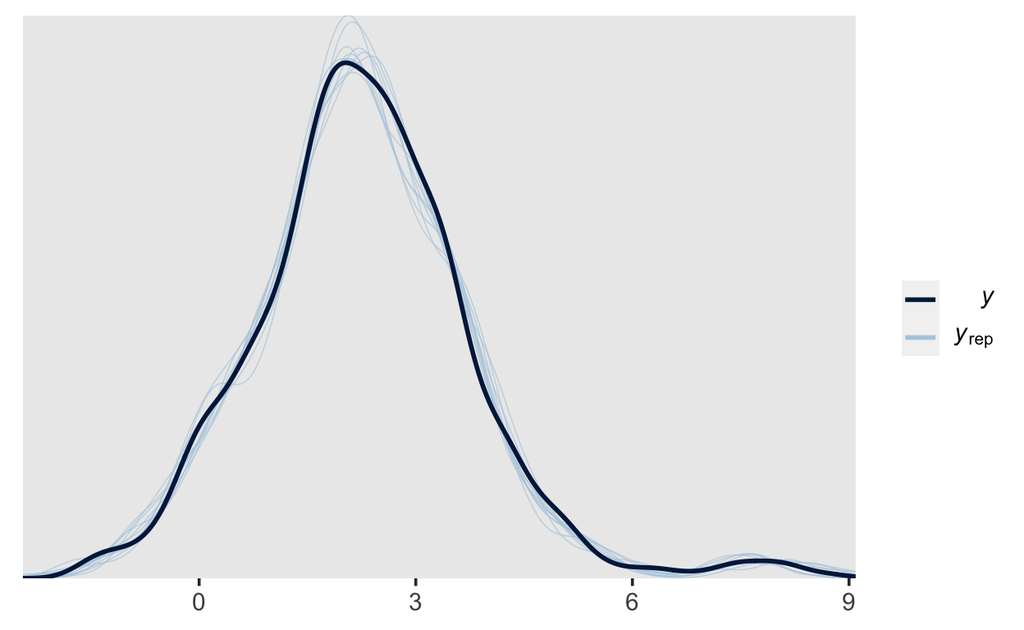

```r
pp_check(fit_null_varying_effects)
```

```r
fit_loo_null <- brm(response ~ 1 + (treatment | subject),
                    prior = prior(lkj(2), class = cor),
                    data = d,
                    iter = 4000,
                    file = "../../models/fit_loo_null-2",
                    file_refit = "on_change")
```

```r
loo_fit_loo_null <- loo(fit_loo_null)
```

```r
loo_compare(loo_fit1, loo_fit_null_varying_effects, loo_fit_loo_null)
```

```
                         elpd_diff se_diff
fit_loo_null              0.0       0.0
fit_null_varying_effects  0.0       0.1
fit1                     -0.4       0.3
```

Let’s try this again, using a bigger true difference between treatment conditions.

```r
set.seed(867)
d2 <- simulate_treatment(n_subjects = 30,
                        a = 3, b = 2,
                        sigma_a = 1, sigma_b = 1.5,
                        rho = -0.2,
                        sigma = 0.5,
                        n_trials = 20)
```

We can plot 12 random subjects to get an idea of what the true means look like.

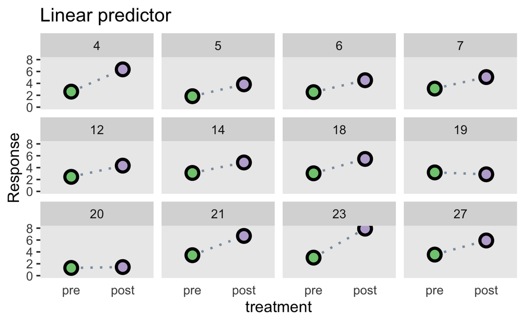

```r
random_subjects <- sample(levels(d2$subject), 12)
d2 |>
  filter(subject %in% random_subjects) |> plot_linpred()
```

```r
priors <- prior(normal(0, 1), class = b) +
  prior(lkj(2), class = cor)

fit2 <- brm(response ~ treatment + (treatment | subject),
                    prior = priors,
                    data = d2,
                    file = "../../models/fit_loo_d2",
                    file_refit = "on_change") |>
  add_criterion("loo")
```

```r
fit_null_2 <- brm(response ~ 1 + (treatment | subject),
                    prior = prior(lkj(2), class = cor),
                    data = d2,
                    iter = 4000,
                    file = "../../models/fit_loo_null_d2",
                    file_refit = "on_change") |>
    add_criterion("loo")
```

```r
loo_compare(fit2, fit_null_2)
```

```
           elpd_diff se_diff
fit2        0.0       0.0
fit_null_2 -0.3       0.5
```

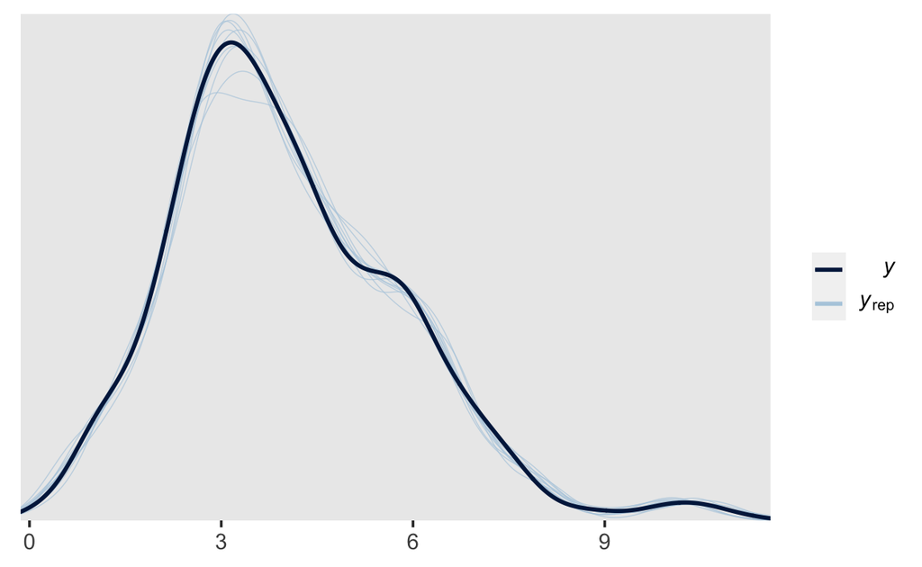

```r
pp_check(fit2)
```

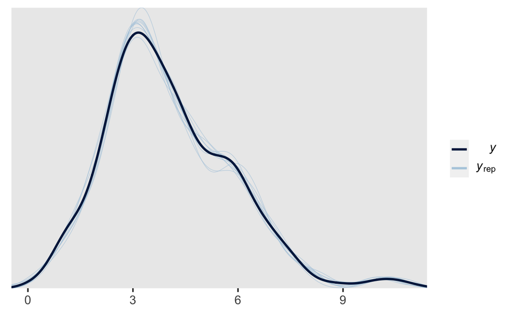

```r
pp_check(fit_null_2)
```

# R^2

The usual definition of $R^2$ (variance of the predicted values $\hat{y}$ divided by the variance of the observations $y$) has problems as a measure of model fit—it always favours models with more parameters (it overfits) and it doesn’t generalize well outside of the single-level Gaussian framework.

However Gelman et al. (2019) have created a Bayesian $R^2$, which is computed as

$$\frac{\text{Explained variance}}{\text{Explained variance} + \text{Residual variance}}$$

The classical $R^2$ is given by

$$\frac{\text{var}(\hat{y})}{\text{var}(y)}$$

```r
bayes_R2(fit2) %>% round(digits = 3)
```

```
   Estimate Est.Error  Q2.5 Q97.5
R2    0.924     0.001 0.921 0.927
```

```r
bayes_R2(fit_null_2) %>% round(digits = 3)
```

```
   Estimate Est.Error  Q2.5 Q97.5
R2    0.924     0.001 0.921 0.927
```

The R package `performance` also implements both conditional and marginal $R^2$ for multilevel models.

- marginal $R^2$ considers only the variance of the fixed effects
- conditional $R^2$ consider both fixed and random effects

# Real-world example

```r
library(lme4)
data("sleepstudy")
```

```r
sleepstudy <- sleepstudy %>%
  as_tibble() %>%
  mutate(Subject = as.character(Subject))
```

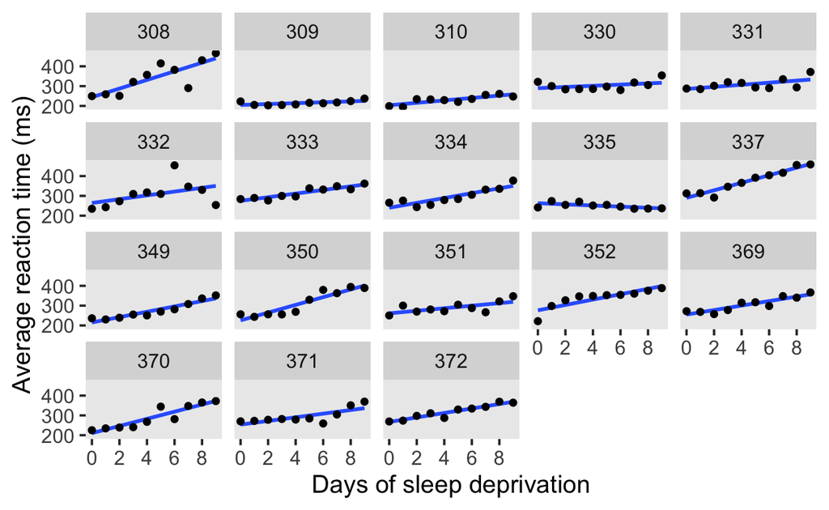

```r
ggplot(sleepstudy) +
  aes(x = Days, y = Reaction) +
  stat_smooth(method = "lm", se = FALSE) +
  geom_point() +
  facet_wrap(~Subject) +
  labs(x = "Days of sleep deprivation",
       y = "Average reaction time (ms)") +
  scale_x_continuous(breaks = 0:4 * 2)
```

```r
fit_no_pooling <- brm(Reaction ~ Days*Subject,
                      prior = prior(normal(0, 10), class = b),
                      data = sleepstudy,
                      file = "../../models/sleepstudy_no_pooling")
```

```r
fit_partial_pooling <- brm(Reaction ~ 1 + Days + (1 + Days | Subject),
                      prior = prior(normal(0, 10), class = b),
                      data = sleepstudy,
                      file = "../../models/sleepstudy_partial_pooling")
```

```r
loo_no_pooling <- loo(fit_no_pooling)
loo_partial_pooling <- loo(fit_partial_pooling)
```

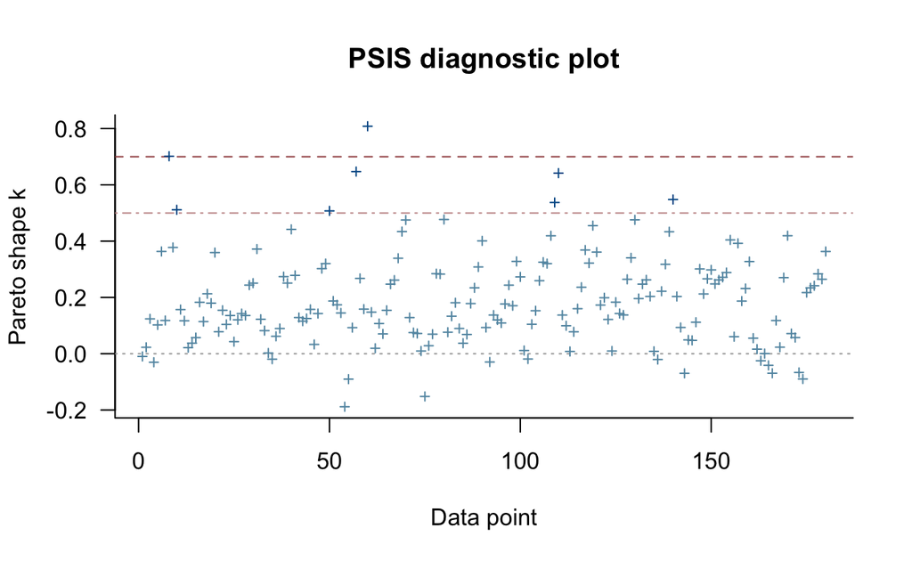

```r
plot(loo_no_pooling)
```

```r
loo_compare(loo_no_pooling, loo_partial_pooling)
```

```
                    elpd_diff se_diff
fit_partial_pooling  0.0       0.0
fit_no_pooling      -7.1       6.7
```

```r
fit_sleep_null_vary_effects <- brm(Reaction ~ 1 + (1 + Days | Subject),
                      prior = prior(lkj(2), class = cor),
                      data = sleepstudy,
                      file = "../../models/fit_sleep_null_vary_effects")
```

```r
loo_sleep_null_vary_effects <- loo(fit_sleep_null_vary_effects)
loo_sleep_null_vary_effects
```

```
Computed from 4000 by 180 log-likelihood matrix

         Estimate   SE
elpd_loo   -862.5 22.8
p_loo        36.2  9.0
looic      1725.1 45.6
------
Monte Carlo SE of elpd_loo is NA.

Pareto k diagnostic values:
                         Count Pct.    Min. n_eff
(-Inf, 0.5]   (good)     174   96.7%   654
 (0.5, 0.7]   (ok)         3    1.7%   277
   (0.7, 1]   (bad)        2    1.1%   11
   (1, Inf)   (very bad)   1    0.6%   9
See help('pareto-k-diagnostic') for details.
```

```r
loo_compare(loo_sleep_null_vary_effects, loo_partial_pooling)
```

```
                            elpd_diff se_diff
fit_partial_pooling          0.0       0.0
fit_sleep_null_vary_effects -1.7       1.5
```

Gelman, Andrew, Ben Goodrich, Jonah Gabry, and Aki Vehtari. 2019. “R-Squared for Bayesian Regression Models.” *The American Statistician* 73 (3): 307–9. https://doi.org/10.1080/00031305.2018.1549100.

Vehtari, Aki, Andrew Gelman, and Jonah Gabry. 2017. “Practical Bayesian Model Evaluation Using Leave-One-Out Cross-Validation and WAIC.” *Statistics and Computing* 27 (5): 1413–32. https://doi.org/10.1007/s11222-016-9696-4.